# Example script for using spin in R

WY Tham

Mar 15, 2017

The easiest way to understand what’s going on here is to first play around with R Markdown or R Notebooks. `spin` is a way of integrating code and text the same way R Markdown does, but works better for situations when you have a lot more code than text, and therefore want to use plain R script i.e. `.R` files rather than `.Rmd` files.

You may find these links from Dean Attali helpful: [general intro to `sping`](http://deanattali.com/2015/03/24/knitrs-best-hidden-gem-spin/) and [`intro to ezknitr`](http://deanattali.com/blog/ezknitr-package/)

You can compile this script with a number of different ways e.g. using the “compile notebook” button in RStudio. Personally, I like to use the `ezspin` command from the `ezknitr` package. This helps to avoid some working directory pains. When I’m ready to compile the script, I’ll run something like the command below in the console:

```r
ezknitr::ezspin("scripts/fake_analysis.R", out_dir = "reports")
```

## Basics

- Any line that starts with `#'` is treated as Markdown.
- Any line that starts with `#+` is treated as a code chunk. Code chunks are how code and text are integrated in R Markdown. You can specify options like `echo = FALSE` as you would in an R Markdown code chunk.

## Example “analysis”

A quick example to show how the code and text integrate. The `gapminder` data is available as a package so you should be able to reproduce this file by just hitting “compile notebook” in RStudio.

```r
library(tidyverse)
library(gapminder)

gapminder
```

```
## # A tibble: 1,704 x 6
##    country     continent  year lifeExp      pop gdpPercap
##    <fct>       <fct>     <int>   <dbl>    <int>     <dbl>
##  1 Afghanistan Asia       1952    28.8  8425333      779.
##  2 Afghanistan Asia       1957    30.3  9240934      821.
##  3 Afghanistan Asia       1962    32.0 10267083      853.
##  4 Afghanistan Asia       1967    34.0 11537966      836.
##  5 Afghanistan Asia       1972    36.1 13079460      740.
##  6 Afghanistan Asia       1977    38.4 14880372      786.
##  7 Afghanistan Asia       1982    39.9 12881816      978.
##  8 Afghanistan Asia       1987    40.8 13867957      852.
##  9 Afghanistan Asia       1992    41.7 16317921      649.
## 10 Afghanistan Asia       1997    41.8 22227415      635.
## # ... with 1,694 more rows
```

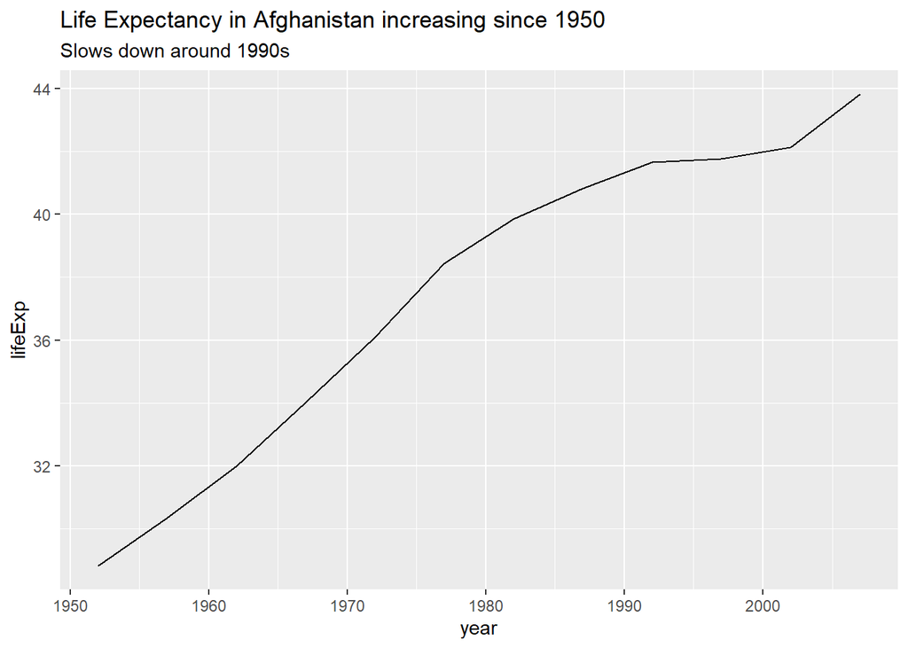

```r
ggplot(filter(gapminder, country == "Afghanistan"), aes(year, lifeExp)) +
  geom_line() +
  labs(title = "Life Expectancy in Afghanistan increasing since 1950",
       subtitle = "Slows down around 1990s")
```